# **Milestone 1**

## **Problem Definition**

**The context:** Why is this problem important to solve?

- It is necessary to diagnose patients with malaria early in order to get them quick treatment to prevent fatalities. Through quick diagnoses, we can solve countless lives by providing treatment to patients with malaria before it becomes far too late.

**The objectives:** What is the intended goal?

- We want to build a machine learning model that can accurately determine if a cell has been infected by a parasite or not given a picture of the cell. By creating an efficient and accurate model, we hope to easily determine if a cell has been infected by Plasmodium parasites to determine whether or not a patient needs treatment for malaria. We also hope to reduce the need for human expertise in diagnosing malaria by tasking a computer to perform diagnosing.

**The key questions:** What are the key questions that need to be answered?

- What key features distinguish a healthy cell with minor blemishes from an infected cell?
- How can we minimize the effect of natural inaccuracies when viewing healthy cells?
- How can we determine between the natural blemishes of normal cells and the ones caused by the parasite infection?

**The problem formulation:** What is it that we are trying to solve using data science?

- Using data science, we want to be able to distinguish between uninfected and parasitized cells so that we can diagnose patients with malaria. We want to be able to quickly diagnose malaria-infected cells without the need for human dependency, which may lead to inaccurate results.

## **Data Description**

There are a total of 24,958 train and 2,600 test images (colored) that we have taken from microscopic images. These images are of the following categories:

**Parasitized:** The parasitized cells contain the Plasmodium parasite which causes malaria  
**Uninfected:** The uninfected cells are free of the Plasmodium parasites

## **Important Notes**

- This notebook can be considered a guide to refer to while solving the problem. The evaluation will be as per the Rubric shared for each Milestone. Unlike previous courses, it does not follow the pattern of the graded questions in different sections. This notebook would give you a direction on what steps need to be taken in order to get a viable solution to the problem. Please note that this is just one way of doing this. There can be other 'creative' ways to solve the problem and we urge you to feel free and explore them as an 'optional' exercise.
- In the notebook, there are markdowns cells called - Observations and Insights. It is a good practice to provide observations and extract insights from the outputs.
- The naming convention for different variables can vary. Please consider the code provided in this notebook as a sample code.
- All the outputs in the notebook are just for reference and can be different if you follow a different approach.
- There are sections called **Think About It** in the notebook that will help you get a better understanding of the reasoning behind a particular technique/step. Interested learners can take alternative approaches if they want to explore different techniques.

### **Mounting the Drive**

```python
#Mounting the drive
from google.colab import drive
drive.mount('/content/drive')
```

### **Loading libraries**

```python
#Importing libraries required to load the data

import zipfile
import os
from PIL import Image
import numpy as np
import pandas as pd
import matplotlib.pyplot as plt
import seaborn as sns

from sklearn.model_selection import train_test_split
from sklearn.preprocessing import MinMaxScaler

import tensorflow as tf
from tensorflow.keras.models import Sequential
from tensorflow.keras.layers import Dense, Conv2D, MaxPool2D, BatchNormalization, Dropout, Flatten, LeakyReLU, GlobalAvgPool2D
from tensorflow.keras.utils import to_categorical
from tensorflow.keras import optimizers

#to ignore warnings
import warnings
warnings.filterwarnings('ignore')

# Remove the limit from the number of displayed columns and rows. It helps to see the entire dataframe while printing it
pd.set_option("display.max_columns", None)
pd.set_option("display.max_rows", 200)
```

### **Let us load the data**

**Note:**

- You must download the dataset from the link provided on Olympus and upload the same on your Google drive before executing the code in the next cell.
- In case of any error, please make sure that the path of the file is correct as the path may be different for you.

```python
#Storing the path of the data file from the Google drive
path = '/content/drive/MyDrive/colab/cell_images.zip'

#The data is provided as a zip file so we need to extract the files from the zip file
with zipfile.ZipFile(path, 'r') as zip_ref:
    zip_ref.extractall()
```

The extracted folder has different folders for train and test data which further contains the different sizes of images for parasitized and uninfected cells within the respective folder name.

The size of all images must be the same and should be converted to 4D arrays so that they can be used as an input for the convolutional neural network. Also, we need to create the labels for both types of images to be able to train and test the model.

Let's do the same for the training data first and then we will use the same code for the test data as well.

```python
#Storing the path of the extracted "train" folder
train_dir = '/content/cell_images/train'

#Size of image so that each image has the same size
SIZE = 64

#Empty list to store the training images after they are converted to NumPy arrays
train_images = []

#Empty list to store the training labels (0 - uninfected, 1 - parasitized)
train_labels = []
```

```python
#We will run the same code for "parasitized" as well as "uninfected" folders within the "train" folder
for folder_name in ['/parasitized/', '/uninfected/']:

    #Path of the folder
    images_path = os.listdir(train_dir + folder_name)

    for i, image_name in enumerate(images_path):
        try:
            #Opening each image using the path of that image
            image = Image.open(train_dir + folder_name + image_name)

            #Resizing each image to (64,64)
            image = image.resize((SIZE, SIZE))

            #Converting images to arrays and appending that array to the empty list defined above
            train_images.append(np.array(image))

            #Creating labels for parasitized and uninfected images
            if folder_name=='/parasitized/':
                train_labels.append(1)
            else:
                train_labels.append(0)
        except Exception:
            pass

#Converting lists to arrays
train_images = np.array(train_images)
train_labels = np.array(train_labels)
```

```python
#Storing the path of the extracted "test" folder
test_dir = '/content/cell_images/test'

#Size of image so that each image has the same size (it must be same as the train image size)
SIZE = 64

#Empty list to store the testing images after they are converted to NumPy arrays
test_images = []

#Empty list to store the testing labels (0 - uninfected, 1 - parasitized)
test_labels = []
```

```python
#We will run the same code for "parasitized" as well as "uninfected" folders within the "test" folder
for folder_name in ['/parasitized/', '/uninfected/']:

    #Path of the folder
    images_path = os.listdir(test_dir + folder_name)

    for i, image_name in enumerate(images_path):
        try:
            #Opening each image using the path of that image
            image = Image.open(test_dir + folder_name + image_name)

            #Resizing each image to (64,64)
            image = image.resize((SIZE, SIZE))

            #Converting images to arrays and appending that array to the empty list defined above
            test_images.append(np.array(image))

            #Creating labels for parasitized and uninfected images
            if folder_name=='/parasitized/':
                test_labels.append(1)
            else:
                test_labels.append(0)
        except Exception:
            pass

#Converting lists to arrays
test_images = np.array(test_images)
test_labels = np.array(test_labels)
```

### **Checking the shape of train and test images**

```python
# shape of images
print(len(train_images))
print(len(test_images))
```

```
24958
2600
```

### **Checking the shape of train and test labels**

```python
# shape of labels
print(len(train_labels))
print(len(test_labels))
```

```
24958
2600
```

##### **Observations and insights:**

- There are 24958 items for both train images and labels
- There are 2600 items for both test images and labels

### **Check the minimum and maximum range of pixel values for train and test images**

```python
# try to use min and max function from numpy
print(train_images.min())
print(train_images.max())
print(test_images.min())
print(test_images.max())
```

```
0
255
0
255
```

##### **Observations and insights:**

- All values for pixels are between 0 and 255 for both the train and test images

### **Count the number of values in both uninfected and parasitized**

```python
# try to use value_counts to count the values
print(np.unique(test_labels, return_counts = True))
print(np.unique(train_labels, return_counts = True))
```

```
(array([0, 1]), array([1300, 1300]))
(array([0, 1]), array([12376, 12582]))
```

### **Normalize the images**

```python
# try to normalize the train and test images by dividing it by 255 and convert them to float32 using astype function
train_images = (train_images / 255).astype('float32')
test_images = (test_images / 255).astype('float32')
```

##### **Observations and insights:**

- For the train set, there are 12376 images of uninfected areas and 12582 images of parasitized areas, which are nearly equal
- For the test set, there are equal amounts of images of uninfected and parasitized

### **Plot to check if the data is balanced**

```
<BarContainer object of 2 artists>
```

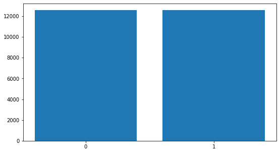

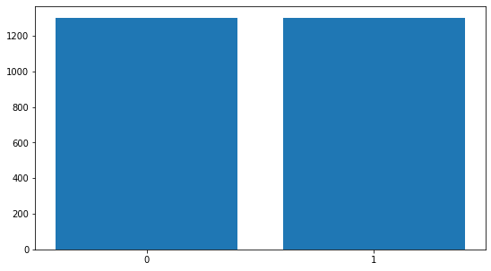

```python
# you are free to use bar plot or pie-plot or count plot, etc. to plot the labels of train and test data and check if they are balanced
plt.figure(figsize=(9, 5))
plt.xticks([0, 1])
plt.bar([0, 1], np.bincount(train_labels)[1:])

plt.figure(figsize=(9, 5))
plt.xticks([0, 1])
plt.bar([0, 1], np.bincount(test_labels)[1:])
```

##### **Observations and insights:**

- The data appear to be balanced between uninfected and parasitized cells

### **Data Exploration**

Let's visualize the images from the train data

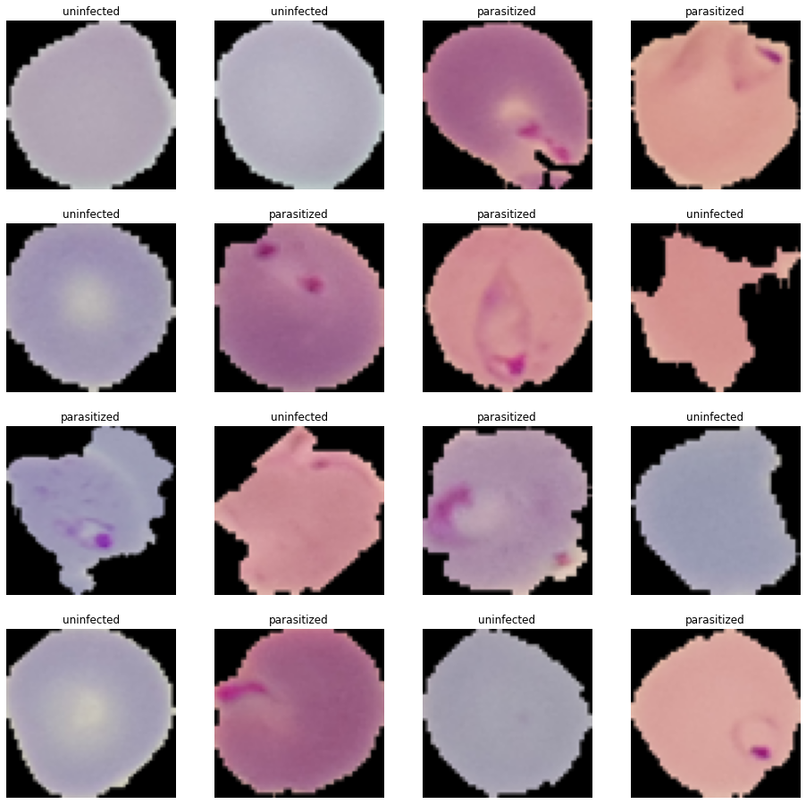

```python
# This code will help you in visualizing both the parasitized and uninfected images
np.random.seed(42)
plt.figure(1 , figsize = (16 , 16))

for n in range(1, 17):
    plt.subplot(4, 4, n)
    index = int(np.random.randint(0, train_images.shape[0], 1))
    if train_labels[index] == 1:
        plt.title('parasitized')
    else:
        plt.title('uninfected')
    plt.imshow(train_images[index])
    plt.axis('off')
```

##### **Observations and insights:**

- Parasitized images seem to have noticeable discoloration inside the respective circles
- Uninfected images seem to have a consistent gradient of color.

### **Similarly visualize the images with subplot(6,6) and figsize=(12,12)**

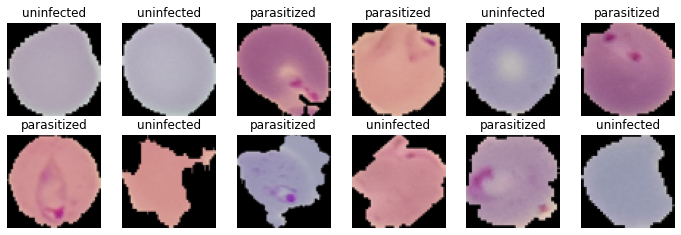

```python
# Hint: Have a keen look into the number of iterations that the for loop should iterate
np.random.seed(42)
plt.figure(1 , figsize = (12 , 12))

for n in range(1, 13):
    plt.subplot(6, 6, n)
    index = int(np.random.randint(0, train_images.shape[0], 1))
    if train_labels[index] == 1:
        plt.title('parasitized')
    else:
        plt.title('uninfected')
    plt.imshow(train_images[index])
    plt.axis('off')
```

##### **Observations and insights:**

- Parasitized images have a prominent discoloration
- Uninfected images are generally one solid color with slight blemishes

### **Plotting the mean images for parasitized and uninfected**

```python
# function to find the mean
def find_mean_img(full_mat, title):
    # calculate the average
    mean_img = np.mean(full_mat, axis = 0)[0]
    # reshape it back to a matrix
    plt.imshow(mean_img)
    plt.title(f'Average {title}')
    plt.axis('off')
    plt.show()
    return mean_img
```

**Mean image for parasitized**

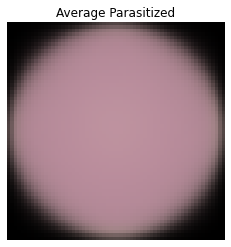

```python
# If the label=1 then the image is parasitised and if the label=0 then the image is uninfected
parasitized_data=[]                                # Create a list to store the parasitized data
for img, label in zip(train_images, train_labels):
        if label==1:
              parasitized_data.append([img])

parasitized_mean = find_mean_img(np.array(parasitized_data), 'Parasitized')   # find the mean
```

**Mean image for uninfected**

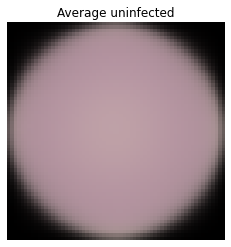

```python
# Similarly write the code to find the mean image of uninfected
uninfected_images=[]                                # Create a list to store the parasitized data
for img, label in zip(train_images, train_labels):
        if label==0:
              uninfected_images.append([img])

uninfected_mean = find_mean_img(np.array(uninfected_images), 'uninfected')
```

##### **Observations and insights:**

- The average of both uninfected and parasitized cells appear very similar
- The average parasitized cell is slightly darker than the average uninfected cell
- Averages will probably not help us very much

### **Converting RGB to HSV of Images using OpenCV**

#### **Converting the train data**

```python
import cv2
gfx=[]   # to hold the HSV image array
for i in np.arange(0,100,1):
  a=cv2.cvtColor(train_images[i],cv2.COLOR_BGR2HSV)
  gfx.append(a)
gfx=np.array(gfx)
```

[output not shown]

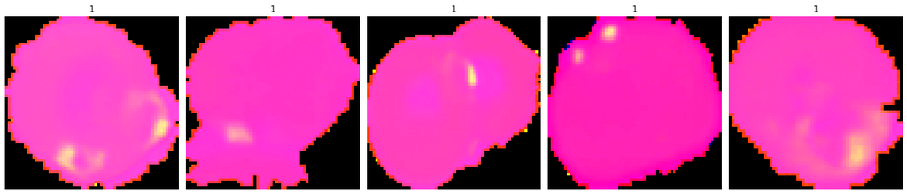

```python
viewimage=np.random.randint(1,100,5)
fig,ax=plt.subplots(1,5,figsize=(18,18))
for t,i in zip(range(5),viewimage):
  Title=train_labels[i]
  ax[t].set_title(Title)
  ax[t].imshow(gfx[i])
  ax[t].set_axis_off()
  fig.tight_layout()
```

#### **Converting the test data**

[output not shown]

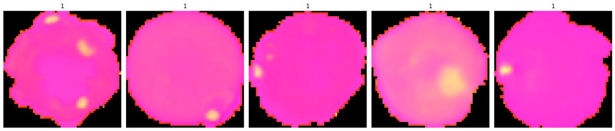

```python
# Similarly you can visualize for the images in the test data
gfx_test=[]
for i in np.arange(0,100,1):
  a=cv2.cvtColor(test_images[i],cv2.COLOR_BGR2HSV)
  gfx_test.append(a)
gfx2=np.array(gfx_test)

viewimage=np.random.randint(1,100,5)
fig,ax=plt.subplots(1,5,figsize=(18,18))
for t,i in zip(range(5),viewimage):
  Title=train_labels[i]
  ax[t].set_title(Title)
  ax[t].imshow(gfx_test[i])
  ax[t].set_axis_off()
  fig.tight_layout()
```

##### **Observations and insights:**

- HSV conversion puts all images, regardless of background color, to one similar format
- Parasitized images appear to have one or more spot of yellowness in the HSV form
- This can help us distinguish between parasitized images and uninfected ones

### **Processing Images using Gaussian Blurring**

#### **Gaussian Blurring on train data**

```python
gbx=[]  ## to hold the blurred images
for i in np.arange(0,100,1):
  b= cv2.GaussianBlur(train_images[i], (5, 5), 0)
  gbx.append(b)
gbx=np.array(gbx)
```

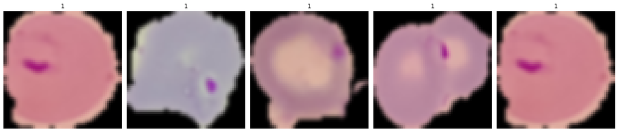

```python
viewimage=np.random.randint(1,100,5)
fig,ax=plt.subplots(1,5,figsize=(18,18))
for t,i in zip(range(5),viewimage):
  Title=train_labels[i]
  ax[t].set_title(Title)
  ax[t].imshow(gbx[i])
  ax[t].set_axis_off()
  fig.tight_layout()
```

#### **Gaussian Blurring on test data**

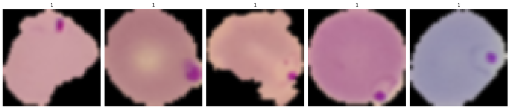

```python
# Similarly you can apply Gaussian blurring for the images in the test data
gbx_test=[]
for i in np.arange(0,100,1):
  b=cv2.GaussianBlur(test_images[i], (5, 5), 0)
  gbx_test.append(b)
gbx_test=np.array(gbx_test)

viewimage=np.random.randint(1,100,5)
fig,ax=plt.subplots(1,5,figsize=(18,18))
for t,i in zip(range(5),viewimage):
  Title=train_labels[i]
  ax[t].set_title(Title)
  ax[t].imshow(gbx_test[i])
  ax[t].set_axis_off()
  fig.tight_layout()
```

- All parasitized images have a very noticeable dark spot even after Gaussian blurring
- This will allow us to determine between parasitized and uninfected images

**Think About It:** Would blurring help us for this problem statement in any way? What else can we try?

- Blurring may help eliminate slight noise in uninfected images and help us identify images with obvious discoloration (parasitized images).

## **Proposed approach**

**Potential techniques:** What different techniques should be explored?

- We should use a CNN as our model
- We want to experiment with different layers for our CNN
- Leaky RELU layers will help us focus on the blemish but too many may eliminate the blemish
- We can experiment with different numbers of convolutional layers
- We could potentially incorporate a dropout layer to reduce overfitting if it becomes a problem
- We will change the number of epochs and the batch size to balance performance and speed

**Overall solution design:** What is the potential solution design?

- Preprocess images with gaussian blurring and HSV conversion
- Gaussian blurring may be helpful as it will eliminate minor noise (blemishes) in our cell images
- HSV conversion will also be helpful as it will put all images, regardless of background color, to one similar format
- Since we are dealing with images, we will use a convolutional neural network
- Leaky RELU layers will help us eliminate unneeded data and only look at the blemish
- Since we want to ignore minor blemishes, we can look at max pooling for our images to capture only the major details
- Since we are determining between two options, we want to use a sigmoid activation function for our output layer
- Other than these, we can add in convolutional layers and a dense layer

**Measures of success:** What are the key measures of success to compare different techniques?

- We want to maximize our recall as diagnosing a person who actually has malaria for quick treatment, which will save countless lives, is much more important than reducing false positives, which will result in a minor waste in resources for hospitals. Therefore, we will primarily focus on recall as our main metric when comparing models.

# **Milestone 2**

### **Mounting the Drive**

```python
#Mounting the drive
from google.colab import drive
drive.mount('/content/drive')
```

### **Loading libraries**

```python
#Importing libraries required to load the data

import zipfile
import os
from PIL import Image
import numpy as np
import pandas as pd
import matplotlib.pyplot as plt
import seaborn as sns

from sklearn.model_selection import train_test_split
from sklearn.preprocessing import MinMaxScaler

import tensorflow as tf
from tensorflow.keras.models import Sequential
from tensorflow.keras.layers import Dense, Conv2D, MaxPool2D, BatchNormalization, Dropout, Flatten, LeakyReLU, GlobalAvgPool2D
from tensorflow.keras.utils import to_categorical
from tensorflow.keras import optimizers

#to ignore warnings
import warnings
warnings.filterwarnings('ignore')

# Remove the limit from the number of displayed columns and rows. It helps to see the entire dataframe while printing it
pd.set_option("display.max_columns", None)
pd.set_option("display.max_rows", 200)
```

### **Let us load the data**

**Note:**

- You must download the dataset from the link provided on Olympus and upload the same on your Google drive before executing the code in the next cell.
- In case of any error, please make sure that the path of the file is correct as the path may be different for you.

```python
#Storing the path of the data file from the Google drive
path = '/content/drive/MyDrive/colab/cell_images.zip'

#The data is provided as a zip file so we need to extract the files from the zip file
with zipfile.ZipFile(path, 'r') as zip_ref:
    zip_ref.extractall()
```

The files have been extracted to the local session of Google Colab. The extracted folder would have the following structure:

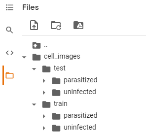

The extracted folder has different folders for train and test data which further contains the different sizes of images for parasitized and uninfected cells within the respective folder name.

The size of all images must be the same and should be converted to 4D arrays so that they can be used as an input for the convolutional neural network. Also, we need to create the labels for both types of images to be able to train and test the model.

Let's do the same for the training data first and then we will use the same code for the test data as well.

```python
#Storing the path of the extracted "train" folder
train_dir = '/content/cell_images/train'

#Size of image so that each image has the same size
SIZE = 64

#Empty list to store the training images after they are converted to NumPy arrays
train_images = []

#Empty list to store the training labels (0 - uninfected, 1 - parasitized)
train_labels = []
```

```python
#We will run the same code for "parasitized" as well as "uninfected" folders within the "train" folder
for folder_name in ['/parasitized/', '/uninfected/']:

    #Path of the folder
    images_path = os.listdir(train_dir + folder_name)

    for i, image_name in enumerate(images_path):
        try:
            #Opening each image using the path of that image
            image = Image.open(train_dir + folder_name + image_name)

            #Resizing each image to (64,64)
            image = image.resize((SIZE, SIZE))

            #Converting images to arrays and appending that array to the empty list defined above
            train_images.append(np.array(image))

            #Creating labels for parasitized and uninfected images
            if folder_name=='/parasitized/':
                train_labels.append(1)
            else:
                train_labels.append(0)
        except Exception:
            pass

#Converting lists to arrays
train_images = np.array(train_images)
train_labels = np.array(train_labels)
```

```python
#Storing the path of the extracted "test" folder
test_dir = '/content/cell_images/test'

#Size of image so that each image has the same size (it must be same as the train image size)
SIZE = 64

#Empty list to store the testing images after they are converted to NumPy arrays
test_images = []

#Empty list to store the testing labels (0 - uninfected, 1 - parasitized)
test_labels = []
```

```python
#We will run the same code for "parasitized" as well as "uninfected" folders within the "test" folder
for folder_name in ['/parasitized/', '/uninfected/']:

    #Path of the folder
    images_path = os.listdir(test_dir + folder_name)

    for i, image_name in enumerate(images_path):
        try:
            #Opening each image using the path of that image
            image = Image.open(test_dir + folder_name + image_name)

            #Resizing each image to (64,64)
            image = image.resize((SIZE, SIZE))

            #Converting images to arrays and appending that array to the empty list defined above
            test_images.append(np.array(image))

            #Creating labels for parasitized and uninfected images
            if folder_name=='/parasitized/':
                test_labels.append(1)
            else:
                test_labels.append(0)
        except Exception:
            pass

#Converting lists to arrays
test_images = np.array(test_images)
test_labels = np.array(test_labels)
```

### **Normalize the images**

```python
# try to normalize the train and test images by dividing it by 255 and convert them to float32 using astype function
train_images = (train_images/255.0).astype('float32')
test_images = (test_images/255.0).astype('float32')
```

As we have done our preprocessing required and performed some EDA to gain some insights in our Milestone-1 so now we will try to build our model and try evaluating its performance.

### **One Hot Encoding on the train and test labels**

```python
# Encoding Train Labels
train_labels=to_categorical(train_labels,2)
# Similarly let us try to encode test labels
test_labels=to_categorical(test_labels,2)
```

### **Base Model**

**Note:** The Base Model has been fully built and evaluated with all outputs shown to give an idea about the process of the creation and evaluation of the performance of a CNN architecture. A similar process can be followed in iterating to build better-performing CNN architectures.

#### **Importing the required libraries**

```python
#Clearing backend
from tensorflow.keras import backend
from tensorflow.keras.utils import to_categorical
from tensorflow.keras.models import Sequential
from tensorflow.keras.layers import Conv2D,MaxPooling2D,Dense,Flatten,Dropout
from tensorflow.keras.callbacks import EarlyStopping, ModelCheckpoint
from random import shuffle

backend.clear_session()
#Fixing the seed for random number generators so that we can ensure we receive the same output everytime
np.random.seed(42)
import random
random.seed(42)
tf.random.set_seed(42)
```

#### **Building the model**

```python
#creating sequential model
model=Sequential()
model.add(Conv2D(filters=32,kernel_size=2,padding="same",activation="relu",input_shape=(64,64,3)))
model.add(MaxPooling2D(pool_size=2))
model.add(Dropout(0.2))
model.add(Conv2D(filters=32,kernel_size=2,padding="same",activation="relu"))
model.add(MaxPooling2D(pool_size=2))
model.add(Dropout(0.2))
model.add(Conv2D(filters=32,kernel_size=2,padding="same",activation="relu"))
model.add(MaxPooling2D(pool_size=2))
model.add(Dropout(0.2))


model.add(Flatten())

model.add(Dense(512,activation="relu"))
model.add(Dropout(0.4))
model.add(Dense(2,activation="softmax"))#2 represent output layer neurons
model.summary()
```

```
Model: "sequential"
_________________________________________________________________
 Layer (type)                Output Shape              Param #
=================================================================
 conv2d (Conv2D)             (None, 64, 64, 32)        416

 max_pooling2d (MaxPooling2D  (None, 32, 32, 32)       0
 )

 dropout (Dropout)           (None, 32, 32, 32)        0

 conv2d_1 (Conv2D)           (None, 32, 32, 32)        4128

 max_pooling2d_1 (MaxPooling  (None, 16, 16, 32)       0
 2D)

 dropout_1 (Dropout)         (None, 16, 16, 32)        0

 conv2d_2 (Conv2D)           (None, 16, 16, 32)        4128

 max_pooling2d_2 (MaxPooling  (None, 8, 8, 32)         0
 2D)

 dropout_2 (Dropout)         (None, 8, 8, 32)          0

 flatten (Flatten)           (None, 2048)              0

 dense (Dense)               (None, 512)               1049088

 dropout_3 (Dropout)         (None, 512)               0

 dense_1 (Dense)             (None, 2)                 1026

=================================================================
Total params: 1,058,786
Trainable params: 1,058,786
Non-trainable params: 0
_________________________________________________________________
```

#### **Compiling the model**

```python
model.compile(loss='binary_crossentropy', optimizer='adam', metrics=['accuracy'])
```

**Using Callbacks**

```python
callbacks = [EarlyStopping(monitor='val_loss', patience=2),
             ModelCheckpoint('.mdl_wts.hdf5', monitor='val_loss', save_best_only=True)]
```

**Fit and train our Model**

```python
#Fit the model with min batch size as 32 can tune batch size to some factor of 2^power ]
history=model.fit(train_images,train_labels,batch_size=32,callbacks=callbacks,validation_split=0.2,epochs=20,verbose=1)
```

#### **Evaluating the model on test data**

```python
accuracy = model.evaluate(test_images, test_labels, verbose=1)
print('\n', 'Test_Accuracy:-', accuracy[1])
```

```
 Test_Accuracy:- 0.9788461327552795
```

**Plotting the confusion matrix**

```
              precision    recall  f1-score   support

           0       0.97      0.99      0.98      1300
           1       0.99      0.97      0.98      1300

    accuracy                           0.98      2600
   macro avg       0.98      0.98      0.98      2600
weighted avg       0.98      0.98      0.98      2600
```

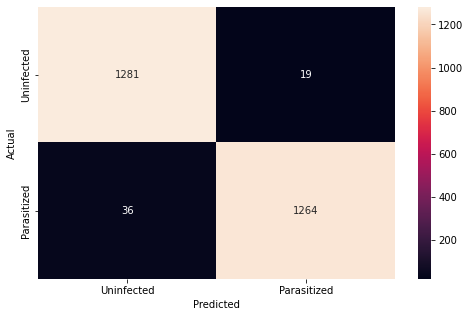

```python
from sklearn.metrics import classification_report
from sklearn.metrics import confusion_matrix

pred = model.predict(test_images)
pred = np.argmax(pred,axis = 1)
y_true = np.argmax(test_labels,axis = 1)

#Printing the classification report
print(classification_report(y_true,pred))

#Plotting the heatmap using confusion matrix
cm = confusion_matrix(y_true,pred)
plt.figure(figsize=(8,5))
sns.heatmap(cm, annot=True,  fmt='.0f', xticklabels=['Uninfected', 'Parasitized'], yticklabels=['Uninfected', 'Parasitized'])
plt.ylabel('Actual')
plt.xlabel('Predicted')
plt.show()
```

**Plotting the train and validation curves**

```python
# function to plot train and validation accuracy
def plot_accuracy(history):
    N = len(history.history["accuracy"])
    plt.figure(figsize=(7,7))
    plt.plot(np.arange(0, N), history.history["accuracy"], label="train_accuracy", ls='--')
    plt.plot(np.arange(0, N), history.history["val_accuracy"], label="val_accuracy", ls='--')
    plt.title("Accuracy vs Epoch")
    plt.xlabel("Epochs")
    plt.ylabel("Accuracy")
    plt.legend(loc="upper left")
```

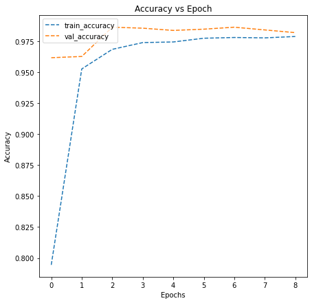

```python
plot_accuracy(history)
```

- Here we can clearly observe that the training and valiation accuracy are increasing
- And we can also notice that validation accuracy is slightly higher than the train accuracy

So now let's try to build another model with few more add on layers and try to check if we can try to improve the model. Therefore try to build a model by adding few layers if required and altering the activation functions.

### **Model 1**

#### **Trying to improve the performance of our model by adding new layers**

```python
#Clearing backend
from tensorflow.keras import backend
from tensorflow.keras.utils import to_categorical
from tensorflow.keras.models import Sequential
from tensorflow.keras.layers import Conv2D,MaxPooling2D,Dense,Flatten,Dropout
from tensorflow.keras.callbacks import EarlyStopping, ModelCheckpoint
from random import shuffle

backend.clear_session()
#Fixing the seed for random number generators so that we can ensure we receive the same output everytime
np.random.seed(42)
import random
random.seed(42)
tf.random.set_seed(42)
```

#### **Building the Model**

```python
#creating sequential model
model1=Sequential()

# Build the model here
model1.add(Conv2D(filters=32,kernel_size=2,padding="same",activation="relu",input_shape=(64,64,3)))
model1.add(Conv2D(filters=32,kernel_size=2,padding="same",activation="relu"))
model1.add(MaxPooling2D(pool_size=2))
model1.add(Conv2D(filters=32,kernel_size=2,padding="same",activation="relu"))
model1.add(MaxPooling2D(pool_size=2))
model1.add(Dropout(0.2))
model1.add(Conv2D(filters=32,kernel_size=2,padding="same",activation="relu"))
model1.add(Conv2D(filters=32,kernel_size=2,padding="same",activation="relu"))
model1.add(MaxPooling2D(pool_size=2))
model1.add(Dropout(0.2))
model1.add(Conv2D(filters=32,kernel_size=2,padding="same",activation="relu"))
model1.add(MaxPooling2D(pool_size=2))
model1.add(Dropout(0.2))


model1.add(Flatten())

model1.add(Dense(512,activation="relu"))
model1.add(Dropout(0.4))
model1.add(Dense(2,activation="softmax"))

model1.summary()
```

```
Model: "sequential_1"
_________________________________________________________________
 Layer (type)                Output Shape              Param #
=================================================================
 conv2d_6 (Conv2D)           (None, 64, 64, 32)        416

 conv2d_7 (Conv2D)           (None, 64, 64, 32)        4128

 max_pooling2d_4 (MaxPooling  (None, 32, 32, 32)       0
 2D)

 conv2d_8 (Conv2D)           (None, 32, 32, 32)        4128

 max_pooling2d_5 (MaxPooling  (None, 16, 16, 32)       0
 2D)

 dropout_5 (Dropout)         (None, 16, 16, 32)        0

 conv2d_9 (Conv2D)           (None, 16, 16, 32)        4128

 conv2d_10 (Conv2D)          (None, 16, 16, 32)        4128

 max_pooling2d_6 (MaxPooling  (None, 8, 8, 32)         0
 2D)

 dropout_6 (Dropout)         (None, 8, 8, 32)          0

 conv2d_11 (Conv2D)          (None, 8, 8, 32)          4128

 max_pooling2d_7 (MaxPooling  (None, 4, 4, 32)         0
 2D)

 dropout_7 (Dropout)         (None, 4, 4, 32)          0

 flatten_1 (Flatten)         (None, 512)               0

 dense_2 (Dense)             (None, 512)               262656

 dropout_8 (Dropout)         (None, 512)               0

 dense_3 (Dense)             (None, 2)                 1026

=================================================================
Total params: 284,738
Trainable params: 284,738
Non-trainable params: 0
_________________________________________________________________
```

#### **Compiling the model**

```python
model1.compile(loss='binary_crossentropy', optimizer='adam', metrics=['accuracy'])
```

**Using Callbacks**

```python
callbacks = [EarlyStopping(monitor='val_loss', patience=2),
             ModelCheckpoint('.mdl_wts.hdf5', monitor='val_loss', save_best_only=True)]
```

**Fit and Train the model**

```python
history1=model1.fit(train_images,train_labels,batch_size=32,callbacks=callbacks,validation_split=0.2,epochs=20,verbose=1)
```

#### **Evaluating the model**

```python
accuracy1 = model1.evaluate(test_images, test_labels, verbose=1)
print('\n', 'Test_Accuracy:-', accuracy1[1])
```

```
 Test_Accuracy:- 0.983846127986908
```

**Plotting the confusion matrix**

```
              precision    recall  f1-score   support

           0       0.98      0.98      0.98      1300
           1       0.98      0.98      0.98      1300

    accuracy                           0.98      2600
   macro avg       0.98      0.98      0.98      2600
weighted avg       0.98      0.98      0.98      2600
```

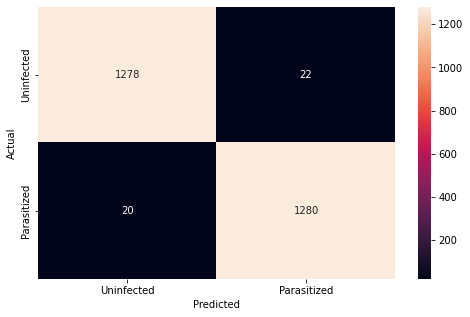

```python
from sklearn.metrics import classification_report
from sklearn.metrics import confusion_matrix

pred = model1.predict(test_images)
pred = np.argmax(pred,axis = 1)
y_true = np.argmax(test_labels,axis = 1)
#Printing the classification report
print(classification_report(y_true,pred))

#Plotting the heatmap using confusion matrix
cm = confusion_matrix(y_true,pred)
plt.figure(figsize=(8,5))
sns.heatmap(cm, annot=True,  fmt='.0f', xticklabels=['Uninfected', 'Parasitized'], yticklabels=['Uninfected', 'Parasitized'])
plt.ylabel('Actual')
plt.xlabel('Predicted')
plt.show()
```

**Plotting the Train and validation curves**

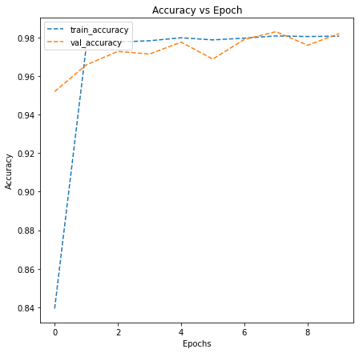

```python
plot_accuracy(history1)
```

#### **Think about it:**

Now let's build a model with LeakyRelu as the activation function

- Can the model performance be improved if we change our activation function to LeakyRelu?
- Can BatchNormalization improve our model?

Let us try to build a model using BatchNormalization and using LeakyRelu as our activation function.

### **Model 2 with Batch Normalization**

```python
#Clearing backend
from tensorflow.keras import backend
backend.clear_session()

#Fixing the seed for random number generators
np.random.seed(42)
import random
random.seed(42)
tf.random.set_seed(42)
```

#### **Building the Model**

```python
model2 = Sequential()
model2.add(Conv2D(32, (3,3), input_shape=(64, 64, 3), padding='same'))
model2.add(LeakyReLU(0.1))
model2.add(Conv2D(filters=32,kernel_size=2,padding="same",activation="relu"))
model2.add(LeakyReLU(0.1))
model2.add(MaxPooling2D(pool_size=2))
model2.add(Dropout(0.2))
model2.add(Conv2D(filters=32,kernel_size=2,padding="same",activation="relu"))
model2.add(LeakyReLU(0.1))
model2.add(MaxPooling2D(pool_size=2))
model2.add(Dropout(0.2))
model2.add(Conv2D(filters=32,kernel_size=2,padding="same",activation="relu"))
model2.add(LeakyReLU(0.1))
model2.add(Conv2D(filters=32,kernel_size=2,padding="same",activation="relu"))
model2.add(LeakyReLU(0.1))
model2.add(MaxPooling2D(pool_size=2))
model2.add(Dropout(0.2))
model2.add(Conv2D(filters=32,kernel_size=2,padding="same",activation="relu"))
model2.add(LeakyReLU(0.1))
model2.add(MaxPooling2D(pool_size=2))
model2.add(Dropout(0.2))

model2.add(BatchNormalization())
model2.add(Flatten())

model2.add(Dense(512,activation="relu"))
model2.add(LeakyReLU(0.1))
model2.add(Dropout(0.4))
model2.add(Dense(2,activation="softmax"))
'''

Complete this model using BatchNormalization layers and by using LeakyRelu as the activation function


'''

adam = optimizers.Adam(learning_rate=0.001)

model2.summary()
```

```
Model: "sequential_15"
_________________________________________________________________
 Layer (type)                Output Shape              Param #
=================================================================
 conv2d_72 (Conv2D)          (None, 64, 64, 32)        896

 leaky_re_lu_87 (LeakyReLU)  (None, 64, 64, 32)        0

 conv2d_73 (Conv2D)          (None, 64, 64, 32)        4128

 leaky_re_lu_88 (LeakyReLU)  (None, 64, 64, 32)        0

 max_pooling2d_48 (MaxPoolin  (None, 32, 32, 32)       0
 g2D)

 dropout_72 (Dropout)        (None, 32, 32, 32)        0

 conv2d_74 (Conv2D)          (None, 32, 32, 32)        4128

 leaky_re_lu_89 (LeakyReLU)  (None, 32, 32, 32)        0

 max_pooling2d_49 (MaxPoolin  (None, 16, 16, 32)       0
 g2D)

 dropout_73 (Dropout)        (None, 16, 16, 32)        0

 conv2d_75 (Conv2D)          (None, 16, 16, 32)        4128

 leaky_re_lu_90 (LeakyReLU)  (None, 16, 16, 32)        0

 conv2d_76 (Conv2D)          (None, 16, 16, 32)        4128

 leaky_re_lu_91 (LeakyReLU)  (None, 16, 16, 32)        0

 max_pooling2d_50 (MaxPoolin  (None, 8, 8, 32)         0
 g2D)

 dropout_74 (Dropout)        (None, 8, 8, 32)          0

 conv2d_77 (Conv2D)          (None, 8, 8, 32)          4128
```

[output cut: 11 more lines]

```
 flatten_15 (Flatten)        (None, 512)               0

 dense_30 (Dense)            (None, 512)               262656

 leaky_re_lu_93 (LeakyReLU)  (None, 512)               0

 dropout_76 (Dropout)        (None, 512)               0

 dense_31 (Dense)            (None, 2)                 1026

=================================================================
Total params: 285,346
Trainable params: 285,282
Non-trainable params: 64
_________________________________________________________________
```

#### **Compiling the model**

```python
model2.compile(loss="binary_crossentropy", optimizer=adam, metrics = ['accuracy'])
```

**Using callbacks**

```python
'''

create the callbacks similarly as done in the base model
As callbacks will help us in saving our checkpoints and stopping at an accuracy where the model doesnot seem to improve

'''
callbacks = [EarlyStopping(monitor='val_loss', patience=2),
             ModelCheckpoint('.mdl_wts.hdf5', monitor='val_loss', save_best_only=True)]
```

**Fit and train the model**

```python
history2 = model2.fit(train_images,train_labels,batch_size=32,callbacks=callbacks,validation_split=0.2,epochs=20,verbose=1)
```

**Plotting the train and validation accuracy**

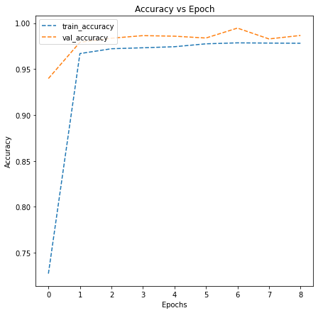

```python
# plotting the accuracies
plot_accuracy(history2)
```

#### **Evaluating the model**

```python
# Evaluate the model to calculate the accuracy
accuracy = model2.evaluate(test_images, test_labels, verbose=1)
print('\n', 'Test_Accuracy:-', accuracy[1])
```

```
 Test_Accuracy:- 0.9834615588188171
```

##### **Observations and insights:**

- LeakyRELU appears to be performing slightly poorly
- LeakyRELU improves false-positive rate but not false-negative rate
- Not helpful to our needs

**Generate the classification report and confusion matrix**

```
              precision    recall  f1-score   support

           0       0.98      0.99      0.98      1300
           1       0.99      0.98      0.98      1300

    accuracy                           0.98      2600
   macro avg       0.98      0.98      0.98      2600
weighted avg       0.98      0.98      0.98      2600
```

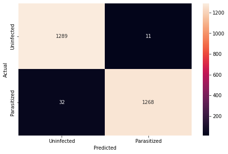

```python
from sklearn.metrics import classification_report
from sklearn.metrics import confusion_matrix

pred = model2.predict(test_images)
pred = np.argmax(pred,axis = 1)
y_true = np.argmax(test_labels,axis = 1)
#Printing the classification report
print(classification_report(y_true,pred))

#Plotting the heatmap using confusion matrix
cm = confusion_matrix(y_true,pred)
plt.figure(figsize=(8,5))
sns.heatmap(cm, annot=True,  fmt='.0f', xticklabels=['Uninfected', 'Parasitized'], yticklabels=['Uninfected', 'Parasitized'])
plt.ylabel('Actual')
plt.xlabel('Predicted')
plt.show()
```

#### **Think About It :**

- Can we improve the model with Image Data Augmentation?
- References to image data augmentation can be seen below:
  - [Image Augmentation for Computer Vision](https://www.mygreatlearning.com/blog/understanding-data-augmentation/)
  - [How to Configure Image Data Augmentation in Keras?](https://machinelearningmastery.com/how-to-configure-image-data-augmentation-when-training-deep-learning-neural-networks/)

### **Model 3 with Data Augmentation**

```python
#Clearing backend
from tensorflow.keras import backend
backend.clear_session()
#Fixing the seed for random number generators
np.random.seed(42)
import random
random.seed(42)
tf.random.set_seed(42)
```

#### **Using image data generator**

```python
from sklearn.model_selection import train_test_split
X_train, X_val, y_train, y_val = train_test_split(train_images, train_labels, test_size=0.2, random_state=42)
from tensorflow.keras.preprocessing.image import ImageDataGenerator

# Using ImageDataGenerator to generate images

train_datagen = ImageDataGenerator(horizontal_flip=True,
                                  zoom_range = 0.5, rotation_range=30)
val_datagen  = ImageDataGenerator()

# Flowing training images using train_datagen generator
train_generator = train_datagen.flow(x = train_images, y = train_labels, batch_size=64, seed=42, shuffle=True)

# Flowing validation images using val_datagen generator
val_generator =  val_datagen.flow(x= test_images, y = test_labels, batch_size=64, seed=42, shuffle=True)
```

#### **Think About It :**

- Check if the performance of the model can be improved by changing different parameters in the ImageDataGenerator.

#### **Visualizing Augmented images**

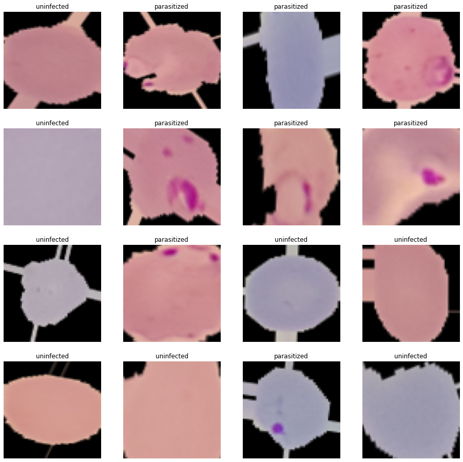

```python
#Creating an iterable for images and labels from the training data
images, labels = next(train_generator)

#Plotting 16 images from the training data
fig, axes = plt.subplots(4, 4, figsize = (16, 8))
fig.set_size_inches(16, 16)
for (image, label, ax) in zip(images, labels, axes.flatten()):
    ax.imshow(image)
    if label[1] == 1:
        ax.set_title('parasitized')
    else:
        ax.set_title('uninfected')
    ax.axis('off')
```

##### **Observations and insights:**

- A vast majority of parasitized images retain their defining discoloration

#### **Building the Model**

```python
model3 = Sequential()

# Build the model here
model3.add(Conv2D(filters=32,kernel_size=2,padding="same",activation="relu",input_shape=(64,64,3)))
model3.add(Conv2D(filters=32,kernel_size=2,padding="same",activation="relu"))
model3.add(MaxPooling2D(pool_size=2))
model3.add(Conv2D(filters=32,kernel_size=2,padding="same",activation="relu"))
model3.add(MaxPooling2D(pool_size=2))
model3.add(Dropout(0.2))
model3.add(Conv2D(filters=32,kernel_size=2,padding="same",activation="relu"))
model3.add(Conv2D(filters=32,kernel_size=2,padding="same",activation="relu"))
model3.add(MaxPooling2D(pool_size=2))
model3.add(Dropout(0.2))
model3.add(Conv2D(filters=32,kernel_size=2,padding="same",activation="relu"))
model3.add(MaxPooling2D(pool_size=2))
model3.add(Dropout(0.2))

model3.add(Flatten())

model3.add(Dense(512,activation="relu"))
model3.add(Dropout(0.4))
model3.add(Dense(2,activation="softmax"))

# use this as the optimizer
adam = optimizers.Adam(learning_rate=0.001)

model3.compile(loss="binary_crossentropy", optimizer=adam, metrics = ['accuracy'])
model3.summary()
```

```
Model: "sequential_3"
_________________________________________________________________
 Layer (type)                Output Shape              Param #
=================================================================
 conv2d_13 (Conv2D)          (None, 64, 64, 32)        416

 conv2d_14 (Conv2D)          (None, 64, 64, 32)        4128

 max_pooling2d_8 (MaxPooling  (None, 32, 32, 32)       0
 2D)

 conv2d_15 (Conv2D)          (None, 32, 32, 32)        4128

 max_pooling2d_9 (MaxPooling  (None, 16, 16, 32)       0
 2D)

 dropout_7 (Dropout)         (None, 16, 16, 32)        0

 conv2d_16 (Conv2D)          (None, 16, 16, 32)        4128

 conv2d_17 (Conv2D)          (None, 16, 16, 32)        4128

 max_pooling2d_10 (MaxPoolin  (None, 8, 8, 32)         0
 g2D)

 dropout_8 (Dropout)         (None, 8, 8, 32)          0

 conv2d_18 (Conv2D)          (None, 8, 8, 32)          4128

 max_pooling2d_11 (MaxPoolin  (None, 4, 4, 32)         0
 g2D)

 dropout_9 (Dropout)         (None, 4, 4, 32)          0

 flatten_1 (Flatten)         (None, 512)               0

 dense_1 (Dense)             (None, 512)               262656

 dropout_10 (Dropout)        (None, 512)               0

 dense_2 (Dense)             (None, 2)                 1026

=================================================================
Total params: 284,738
Trainable params: 284,738
Non-trainable params: 0
_________________________________________________________________
```

**Using Callbacks**

```python
callbacks = [EarlyStopping(monitor='val_loss', patience=2),
             ModelCheckpoint('.mdl_wts.hdf5', monitor='val_loss', save_best_only=True)]
```

**Fit and Train the model**

```python
history3 = model3.fit(train_generator, validation_data=val_generator,batch_size=32,callbacks=callbacks, epochs=20, verbose=1)
```

#### **Evaluating the model**

**Plot the train and validation accuracy**

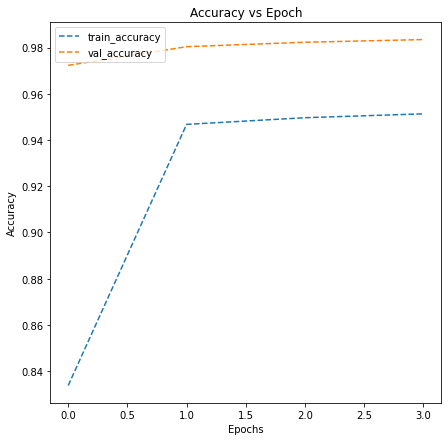

```python
# plotting the accuracies
plot_accuracy(history3)
```

```python
# Evaluating the model on test data
accuracy3 = model3.evaluate(test_images, test_labels, verbose=1)
print('\n', 'Test_Accuracy:-', accuracy3[1])
```

```
 Test_Accuracy:- 0.9834615588188171
```

**Plotting the classification report and confusion matrix**

```
              precision    recall  f1-score   support

           0       1.00      0.97      0.98      1300
           1       0.97      1.00      0.98      1300

    accuracy                           0.98      2600
   macro avg       0.98      0.98      0.98      2600
weighted avg       0.98      0.98      0.98      2600
```

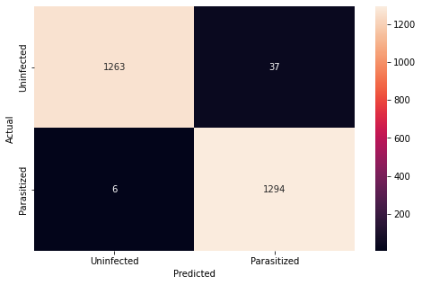

```python
from sklearn.metrics import classification_report
from sklearn.metrics import confusion_matrix

pred = model3.predict(test_images)
pred = np.argmax(pred,axis = 1)
y_true = np.argmax(test_labels,axis = 1)
#Printing the classification report
print(classification_report(y_true,pred))

#Plotting the heatmap using confusion matrix
cm = confusion_matrix(y_true,pred)
plt.figure(figsize=(8,5))
sns.heatmap(cm, annot=True,  fmt='.0f', xticklabels=['Uninfected', 'Parasitized'], yticklabels=['Uninfected', 'Parasitized'])
plt.ylabel('Actual')
plt.xlabel('Predicted')
plt.show()
```

**Now let us try to use a pretrained model like VGG16 and check how it performs on our data.**

### **Pre-trained model (VGG16)**

```python
#Clearing backend
from tensorflow.keras import backend
backend.clear_session()
#Fixing the seed for random number generators
np.random.seed(42)
import random
random.seed(42)
tf.random.set_seed(42)
```

```python
from tensorflow.keras.applications.vgg16 import VGG16
from tensorflow.keras import Model

vgg = VGG16(include_top=False, weights='imagenet', input_shape=(64,64,3))
vgg.summary()
```

```
Downloading data from https://storage.googleapis.com/tensorflow/keras-applications/vgg16/vgg16_weights_tf_dim_ordering_tf_kernels_notop.h5
Model: "vgg16"
_________________________________________________________________
 Layer (type)                Output Shape              Param #
=================================================================
 input_1 (InputLayer)        [(None, 64, 64, 3)]       0

 block1_conv1 (Conv2D)       (None, 64, 64, 64)        1792

 block1_conv2 (Conv2D)       (None, 64, 64, 64)        36928

 block1_pool (MaxPooling2D)  (None, 32, 32, 64)        0

 block2_conv1 (Conv2D)       (None, 32, 32, 128)       73856

 block2_conv2 (Conv2D)       (None, 32, 32, 128)       147584

 block2_pool (MaxPooling2D)  (None, 16, 16, 128)       0

 block3_conv1 (Conv2D)       (None, 16, 16, 256)       295168

 block3_conv2 (Conv2D)       (None, 16, 16, 256)       590080

 block3_conv3 (Conv2D)       (None, 16, 16, 256)       590080

 block3_pool (MaxPooling2D)  (None, 8, 8, 256)         0

 block4_conv1 (Conv2D)       (None, 8, 8, 512)         1180160

 block4_conv2 (Conv2D)       (None, 8, 8, 512)         2359808

 block4_conv3 (Conv2D)       (None, 8, 8, 512)         2359808

 block4_pool (MaxPooling2D)  (None, 4, 4, 512)         0

 block5_conv1 (Conv2D)       (None, 4, 4, 512)         2359808

 block5_conv2 (Conv2D)       (None, 4, 4, 512)         2359808

 block5_conv3 (Conv2D)       (None, 4, 4, 512)         2359808

 block5_pool (MaxPooling2D)  (None, 2, 2, 512)         0

=================================================================
Total params: 14,714,688
Trainable params: 14,714,688
Non-trainable params: 0
_________________________________________________________________
```

```python
transfer_layer = vgg.get_layer('block5_pool')
vgg.trainable=False

# Add classification layers on top of it

x = Flatten()(transfer_layer.output) #Flatten the output from the 3rd block of the VGG16 model
x = Dense(256, activation='relu')(x)

# Similarly add a dense layer with 128 neurons
x = Dense(128, activation='relu')(x)
x = Dropout(0.3)(x)

# Add a dense layer with 64 neurons
x = Dense(64, activation='relu')(x)

x = BatchNormalization()(x)
pred = Dense(2, activation='softmax')(x)

model4 = Model(vgg.input, pred) #Initializing the model
```

#### **Compiling the model**

```python
# Compiling the model
adam = optimizers.Adam(learning_rate=0.001)

model4.compile(loss="binary_crossentropy", optimizer=adam, metrics = ['accuracy'])
model4.summary()
```

```
Model: "model_1"
_________________________________________________________________
 Layer (type)                Output Shape              Param #
=================================================================
 input_1 (InputLayer)        [(None, 64, 64, 3)]       0

 block1_conv1 (Conv2D)       (None, 64, 64, 64)        1792

 block1_conv2 (Conv2D)       (None, 64, 64, 64)        36928

 block1_pool (MaxPooling2D)  (None, 32, 32, 64)        0

 block2_conv1 (Conv2D)       (None, 32, 32, 128)       73856

 block2_conv2 (Conv2D)       (None, 32, 32, 128)       147584

 block2_pool (MaxPooling2D)  (None, 16, 16, 128)       0

 block3_conv1 (Conv2D)       (None, 16, 16, 256)       295168

 block3_conv2 (Conv2D)       (None, 16, 16, 256)       590080

 block3_conv3 (Conv2D)       (None, 16, 16, 256)       590080

 block3_pool (MaxPooling2D)  (None, 8, 8, 256)         0

 block4_conv1 (Conv2D)       (None, 8, 8, 512)         1180160

 block4_conv2 (Conv2D)       (None, 8, 8, 512)         2359808

 block4_conv3 (Conv2D)       (None, 8, 8, 512)         2359808

 block4_pool (MaxPooling2D)  (None, 4, 4, 512)         0

 block5_conv1 (Conv2D)       (None, 4, 4, 512)         2359808

 block5_conv2 (Conv2D)       (None, 4, 4, 512)         2359808

 block5_conv3 (Conv2D)       (None, 4, 4, 512)         2359808

 block5_pool (MaxPooling2D)  (None, 2, 2, 512)         0

 flatten_1 (Flatten)         (None, 2048)              0

 dense_2 (Dense)             (None, 256)               524544

 dense_3 (Dense)             (None, 128)               32896

 dropout_1 (Dropout)         (None, 128)               0

 dense_4 (Dense)             (None, 64)                8256

 batch_normalization_1 (Batc  (None, 64)               256
 hNormalization)

 dense_5 (Dense)             (None, 2)                 130

=================================================================
Total params: 15,280,770
Trainable params: 565,954
Non-trainable params: 14,714,816
_________________________________________________________________
```

**using callbacks**

```python
# Adding Callbacks to the model
callbacks = [EarlyStopping(monitor='val_loss', patience=2),
             ModelCheckpoint('.mdl_wts.hdf5', monitor='val_loss', save_best_only=True)]
```

**Fit and Train the model**

```python
#Fitting the model and running the model for 10 epochs
history4 = model4.fit(
            train_images, train_labels,
            epochs=10,
            callbacks=callbacks,
            batch_size=32,
            validation_split=0.2,
            verbose=1
)
```

**Plot the train and validation accuracy**

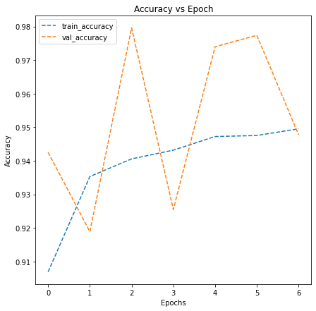

```python
# plotting the accuracies
plot_accuracy(history4)
```

##### **Observations and insights:**

- What can be observed from the validation and train curves?
- The train curve increases with the number of epochs
- However, the validation curve wildly varies based on number of epochs showing signs of potential overfitting.

#### **Evaluating the model**

```python
# Evaluating the model on test data
accuracy4 = model4.evaluate(test_images, test_labels, verbose=1)
print('\n', 'Test_Accuracy:-', accuracy4[1])
```

```
 Test_Accuracy:- 0.9384615421295166
```

**Plotting the classification report and confusion matrix**

```
              precision    recall  f1-score   support

           0       0.96      0.91      0.94      1300
           1       0.92      0.96      0.94      1300

    accuracy                           0.94      2600
   macro avg       0.94      0.94      0.94      2600
weighted avg       0.94      0.94      0.94      2600
```

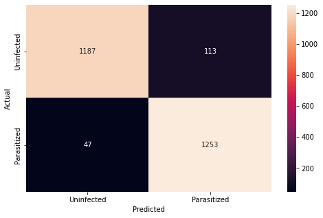

```python
# Plot the confusion matrix and generate a classification report for the model
from sklearn.metrics import classification_report
from sklearn.metrics import confusion_matrix

pred = model4.predict(test_images)
pred = np.argmax(pred,axis = 1)
y_true = np.argmax(test_labels,axis = 1)
#Printing the classification report
print(classification_report(y_true,pred))

#Plotting the heatmap using confusion matrix
cm = confusion_matrix(y_true,pred)
plt.figure(figsize=(8,5))
sns.heatmap(cm, annot=True,  fmt='.0f', xticklabels=['Uninfected', 'Parasitized'], yticklabels=['Uninfected', 'Parasitized'])
plt.ylabel('Actual')
plt.xlabel('Predicted')
plt.show()
```

#### **Think about it:**

- What observations and insights can be drawn from the confusion matrix and classification report?
- Choosw the model with the best accuracy scores from all the above models and save it as a final model.

**Improvements that can be done:**

- Can the model performance be improved using other pre-trained models or different CNN architecture?
- You can try to build a model using these HSV images and compare them with your other models.

### **Insights**

#### **Refined insights**:

- What are the most meaningful insights from the data relevant to the problem?
- Parasitized cells have defining dark spot
- Regular cells may have gradients of color
- Data augmentation retains dark spots
- We can reliably train machine learning models to detect these dark spots in cell images
- Neural networks can be reliably used to detect malaria in cells

#### **Proposal for the final solution design**:

- What model do you propose to be adopted? Why is this the best solution to adopt?
- We will use model 3 which incorporates data augmentation for the model. It is the best solution because it gives us the highest recall rate of ~100% and the lowest number of false negatives (6), which is what we are trying to avoid.